# North Beach Fort Cam

```r
Box.test(residual_nbf_hour_model_1, type = c("Box-Pierce"))
```

```
##
##  Box-Pierce test
##
## data:  residual_nbf_hour_model_1
## X-squared = 0.0072911, df = 1, p-value = 0.932
```

```r
Box.test(residual_nbf_hour_model_1, lag = 24, type = c("Box-Pierce"))
```

```
##
##  Box-Pierce test
##
## data:  residual_nbf_hour_model_1
## X-squared = 12.563, df = 24, p-value = 0.9728
```

```r
# Both the Box-Pierce test and the Ljung-Box test give p-vlaues greater than 0.05. I fail to reject the null
```

Then I try the model without the seasonal component. ACF and PACF plots show almost no significant spike and both the Box-Pierce tests and give p-values greater than 0.05. I fail to reject the null and conclude that the residuals are identically independently distributed.

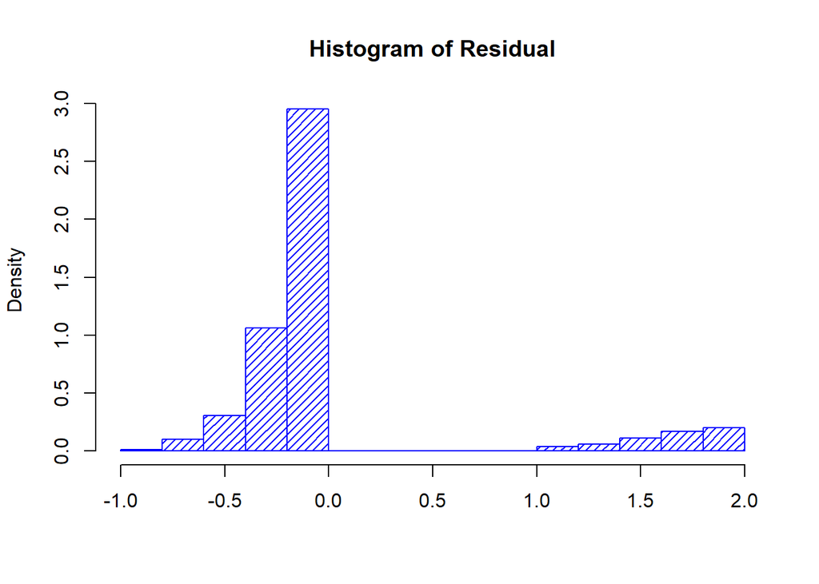

```r
nbf_hour_model_2 <-arima(nbf_hour_ts_train, order=c(1,0,3))

#### Model diagnosis - auto.arima ####
# 1. Normality test
residual_nbf_hour_model_2 <- residuals(nbf_hour_model_2)
hist(residual_nbf_hour_model_2,density=20,breaks=20,col="blue",xlab="",main = "Histogram of Residual",prob=TRUE)
```

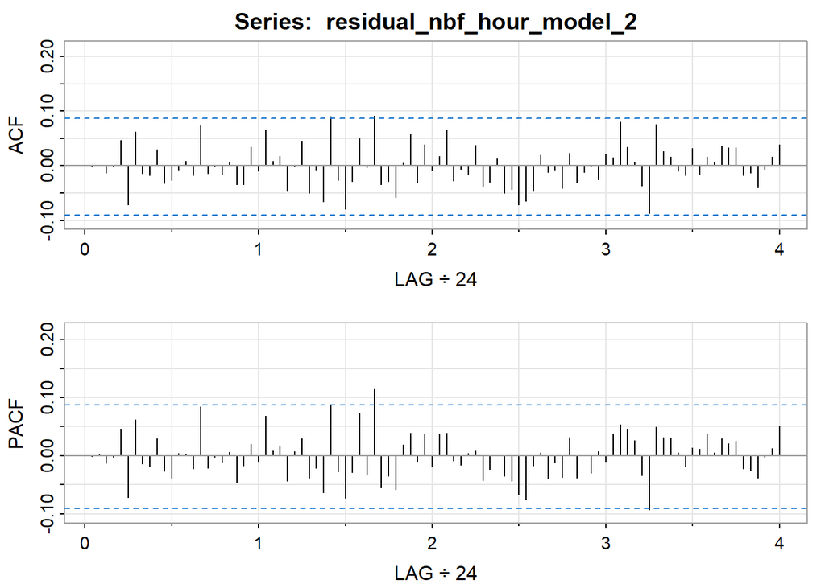

```
##      [,1] [,2]  [,3] [,4] [,5]  [,6] [,7]  [,8]  [,9] [,10] [,11] [,12] [,13]
## ACF     0    0 -0.01    0 0.05 -0.07 0.06 -0.01 -0.02  0.03 -0.03 -0.03 -0.01
## PACF    0    0 -0.01    0 0.05 -0.07 0.06 -0.01 -0.02  0.03 -0.03 -0.04  0.00
##      [,14] [,15] [,16] [,17] [,18] [,19] [,20] [,21] [,22] [,23] [,24] [,25]
## ACF   0.01 -0.02  0.07 -0.01     0 -0.02  0.01 -0.03 -0.03  0.03 -0.01  0.06
## PACF  0.00 -0.02  0.08 -0.02     0 -0.01  0.01 -0.05 -0.02  0.02 -0.01  0.07
##      [,26] [,27] [,28] [,29] [,30] [,31] [,32] [,33] [,34] [,35] [,36] [,37]
## ACF   0.01  0.02 -0.05  0.00  0.05 -0.05 -0.01 -0.07  0.09 -0.03 -0.08 -0.03
## PACF  0.01  0.02 -0.04  0.01  0.03 -0.04 -0.02 -0.06  0.09 -0.03 -0.07 -0.03
##      [,38] [,39] [,40] [,41] [,42] [,43] [,44] [,45] [,46] [,47] [,48] [,49]
## ACF   0.05  0.00  0.09 -0.03 -0.03 -0.06  0.01  0.06 -0.03  0.04 -0.01  0.02
## PACF  0.07 -0.03  0.12 -0.05 -0.03 -0.06  0.02  0.04 -0.01  0.04 -0.02  0.04
##      [,50] [,51] [,52] [,53] [,54] [,55] [,56] [,57] [,58] [,59] [,60] [,61]
## ACF   0.07 -0.03 -0.01 -0.02  0.04 -0.04 -0.03  0.01 -0.05 -0.04 -0.07 -0.06
## PACF  0.04 -0.01 -0.02  0.00  0.01 -0.04 -0.02  0.00 -0.03 -0.04 -0.07 -0.08
##      [,62] [,63] [,64] [,65] [,66] [,67] [,68] [,69] [,70] [,71] [,72] [,73]
## ACF  -0.05  0.02 -0.01 -0.01 -0.04  0.02 -0.03 -0.01  0.00 -0.03  0.02  0.02
## PACF -0.02  0.01 -0.04 -0.01 -0.04  0.03 -0.04  0.00 -0.03  0.01 -0.01  0.04
##      [,74] [,75] [,76] [,77] [,78] [,79] [,80] [,81] [,82] [,83] [,84] [,85]
## ACF   0.08  0.03  0.01 -0.04 -0.09  0.08  0.03  0.02 -0.01 -0.02  0.03 -0.01
## PACF  0.05  0.05  0.03 -0.03 -0.09  0.05  0.03  0.03  0.00 -0.02  0.01  0.01
##      [,86] [,87] [,88] [,89] [,90] [,91] [,92] [,93] [,94] [,95] [,96]
## ACF   0.02  0.01  0.04  0.03  0.03 -0.02 -0.01 -0.04 -0.01  0.02  0.04
## PACF  0.04  0.00  0.03  0.02  0.02 -0.02 -0.03 -0.04  0.00  0.01  0.05
```

```r
# 2. Correlation test
acf2(residual_nbf_hour_model_2)
```

```r
Box.test(residual_nbf_hour_model_2, lag = 24, type = c("Box-Pierce"))
```

```
##
##  Box-Pierce test
##
## data:  residual_nbf_hour_model_2
## X-squared = 12.254, df = 24, p-value = 0.9769
```

```r
Box.test(residual_nbf_hour_model_2, lag = 24, type = c("Ljung-Box"))
```

```
##
##  Box-Ljung test
##
## data:  residual_nbf_hour_model_2
## X-squared = 12.595, df = 24, p-value = 0.9723
```

```r
# Both the Box-Pierce test and the Ljung-Box test give p-vlaues greater than 0.05. I fail to reject the null
```

```r
### Summary of the created model.
result <- AIC(nbf_hour_model_auto, nbf_hour_model_1, nbf_hour_model_2)
models <- list(nbf_hour_model_auto, nbf_hour_model_1, nbf_hour_model_2)
result$BIC <- sapply(models, BIC)
kable(result, digits = 2, align = "c")
```

|  | df | AIC | BIC |
| --- | --- | --- | --- |
| nbf_hour_model_auto | 5 | 950.86 | 971.98 |
| nbf_hour_model_1 | 6 | 949.79 | 975.13 |
| nbf_hour_model_2 | 6 | 949.41 | 974.76 |

The three models are almost equivalently good based on their AIC and BIC values.

```r
summary(nbf_hour_model_1)
```

```
##
## Call:
## arima(x = nbf_hour_ts_train, order = c(3, 0, 1))
##
## Coefficients:
##          ar1      ar2     ar3      ma1  intercept
##       0.7242  -0.0376  0.0972  -0.6091     -1.270
## s.e.  0.1472   0.0578  0.0522   0.1435      0.049
##
## sigma^2 estimated as 0.3749:  log likelihood = -468.89,  aic = 949.79
##
## Training set error measures:
##                        ME      RMSE       MAE     MPE    MAPE     MASE
## Training set -0.002276735 0.6122761 0.3812326 53.5121 53.5121 1.120177
##                      ACF1
## Training set -0.003799705
```

```r
summary(nbf_hour_model_2)
```

```
##
## Call:
## arima(x = nbf_hour_ts_train, order = c(1, 0, 3))
##
## Coefficients:
##          ar1      ma1      ma2     ma3  intercept
##       0.7885  -0.6762  -0.0463  0.0979    -1.2704
## s.e.  0.0950   0.1026   0.0548  0.0510     0.0481
##
## sigma^2 estimated as 0.3746:  log likelihood = -468.7,  aic = 949.41
##
## Training set error measures:
##                        ME      RMSE       MAE      MPE     MAPE     MASE
## Training set -0.002102334 0.6120436 0.3806724 53.43533 53.43533 1.118531
##                      ACF1
## Training set -0.001095363
```

Model 1: $ARMA(3,0,1)$, mathematically, it is the following:

$(1 - 0.7242B + 0.0376B^2 - 0.0972B^3)Y_{t} = (1 -0.6091B)\epsilon_{t}$

$Y_t = - 1.270 + 0.7242Y_{t-1} - 0.0376Y_{t-2} + 0.0972Y_{t-3} + \epsilon_{t} - 0.6091\epsilon_{t-1}$

Model 2: $ARMA(1,0,3)$, mathematically, it is the following:

$(1 - 0.7885B)Y_{t} = (1 -0.6762B - 0.0463B^2 + 0.0979B^3)\epsilon_{t}$

$Y_t = - 1.2704 + 0.7885Y_{t-1} + \epsilon_{t} - 0.6762\epsilon_{t-1} - 0.0463\epsilon_{t-2} + 0.0979\epsilon_{t-3}$

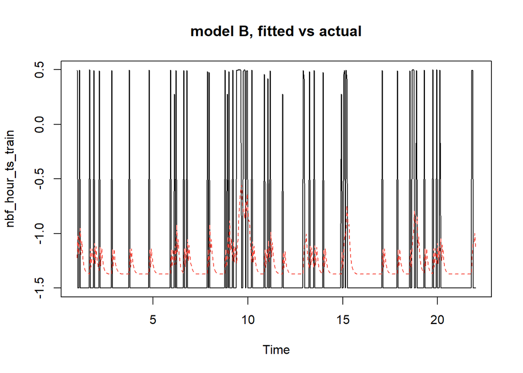

```r
# Plot the fitted values with raw data
nbf_hour_fitted_1 <- nbf_hour_ts_train - residual_nbf_hour_model_1
ts.plot(nbf_hour_ts_train, main = 'model B, fitted vs actual')
points(nbf_hour_fitted_1, type = "l", col = 2, lty = 2)
```

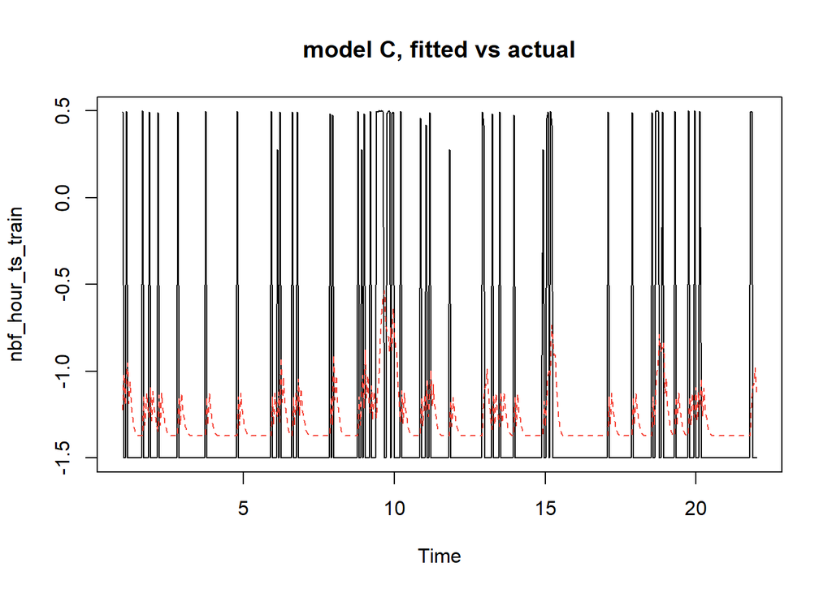

```r
nbf_hour_fitted_2 <- nbf_hour_ts_train - residual_nbf_hour_model_2
ts.plot(nbf_hour_ts_train, main = 'model C, fitted vs actual')
points(nbf_hour_fitted_2, type = "l", col = 2, lty = 2)
```

Here, I plot the fitted values of the two models with the transformed data.

### North Beach Fort Cam - Forecast

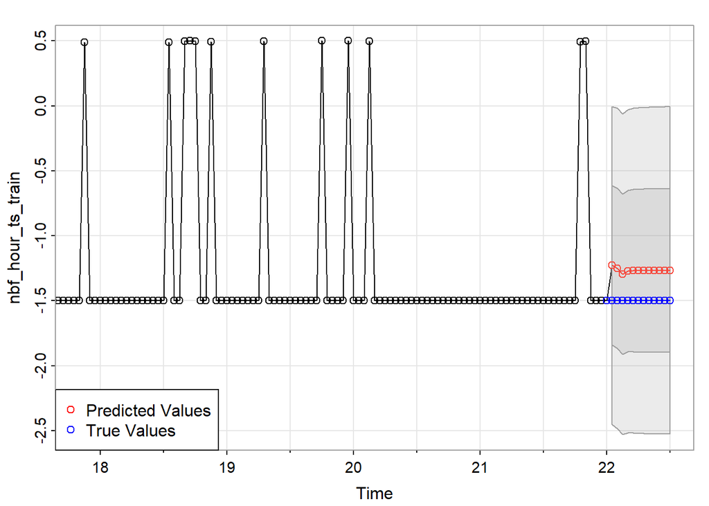

```r
# Plot the forecast values with actual data
pred_auto <- sarima.for(nbf_hour_ts_train, n.ahead=12, plot.all=F, p=3, d=0, q=1, P=2, D=0, Q=0, S=0)
lines(nbf_hour_ts_test, col="blue")
points(nbf_hour_ts_test, col="blue")
legend("bottomleft", pch=1, col=c("red", "blue"), legend=c("Predicted Values", "True Values"))
```

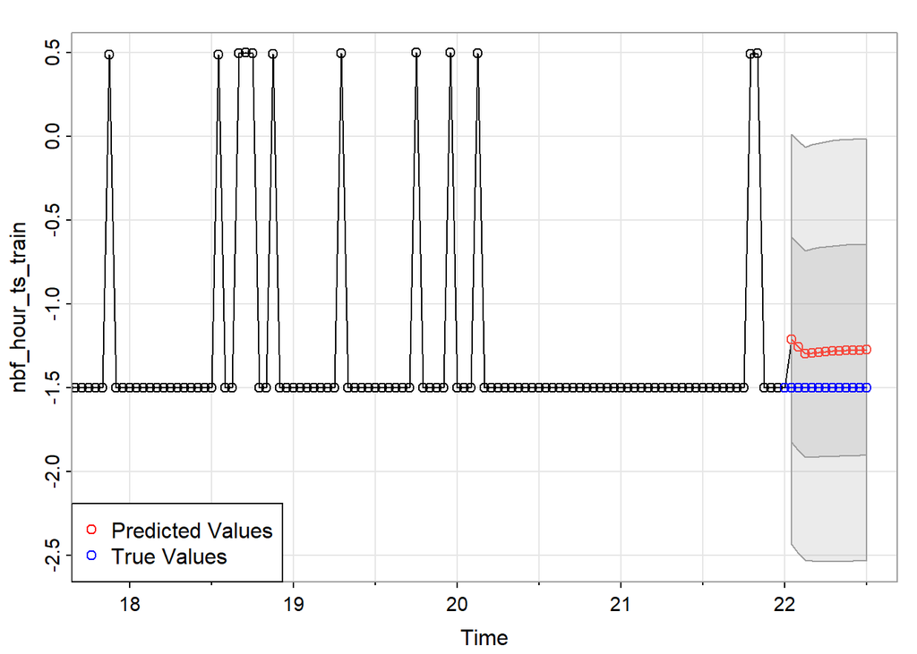

```r
pred_1 <- sarima.for(nbf_hour_ts_train, n.ahead=12, plot.all=F, p=1, d=0, q=3, P=0, D=0, Q=0, S=0)
lines(nbf_hour_ts_test, col="blue")
points(nbf_hour_ts_test, col="blue")
legend("bottomleft", pch=1, col=c("red", "blue"), legend=c("Predicted Values", "True Values"))
```

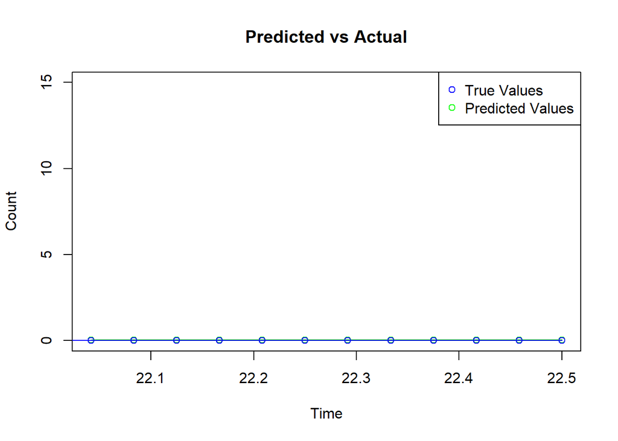

```r
nbf_forecast_1 <- forecast::forecast(nbf_hour_model_auto,h=12,level=c(0.95))
nbf_forecast_2 <- forecast::forecast(nbf_hour_model_2,h=12,level=c(0.95))

nbf_next10 <- (lambda_bc_nbf_hour_ts*nbf_forecast_2$mean + 1)^(1/lambda_bc_nbf_hour_ts) - 0.5
# reverse the Box-Cox transformation

plot(nbf_next10, ylim = c(0,15), col = "green", ylab = "Count", main = "Predicted vs Actual")
points(nbf_next10, col = "green")
lines(nbf_hour_ts_test_1, col = "blue")
points(nbf_hour_ts_test_1, col = "blue")
legend("topright", pch=1, col=c("blue", "green"),
       legend=c("True Values", "Predicted Values"))
```